# ttesst

## T-test in R

We want to check if there is a difference in the average weight between the control (normal diet) and treatment (high fat diet) group. Data has already been imported and converted to numeric vectors (n=12). The arguments could also be a of type *data.frame*.

### Assumptions:

*The measured variable is normally distributed in the population. Only then does the t-statistic follow the t-distribution. If n was larger than 30, we could work with the normal distribution. The following qqplots help evaluating the distribution:

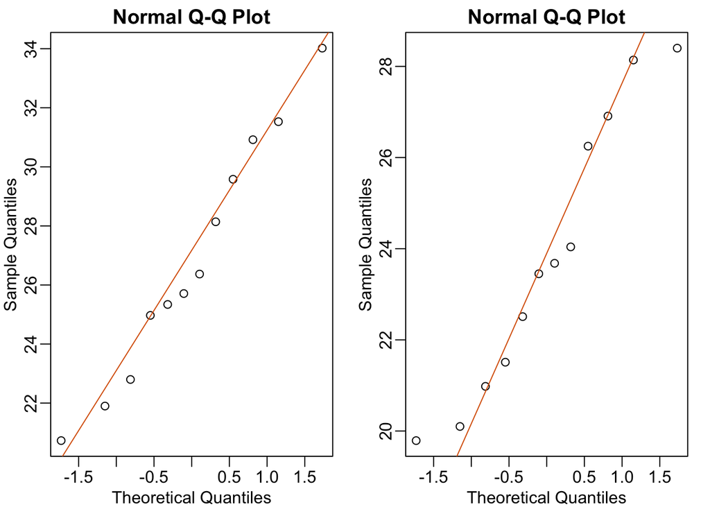

```r
library(rafalib)
mypar(1,2)

qqnorm(treatment)
qqline(treatment,col=2)

qqnorm(control)
qqline(control,col=2)
```

### T-test function in R:

```r
result <- t.test(treatment,control)
result$p.value
```

```
## [1] 0.05299888
```

```r
result
```

```
##
##  Welch Two Sample t-test
##
## data:  treatment and control
## t = 2.0552, df = 20.236, p-value = 0.053
## alternative hypothesis: true difference in means is not equal to 0
## 95 percent confidence interval:
##  -0.04296563  6.08463229
## sample estimates:
## mean of x mean of y
##  26.83417  23.81333
```

### The following exercises are copied from the edx course ‘HarvardX: PH525.1x Statistics and R’:

This is a large dataset (1,236 cases), and we will pretend that it contains the entire population in which we are interested. We will study the differences in birth weight between babies born to smoking and non-smoking mothers.

First, let’s split this into two birth weight datasets: one of birth weights to non-smoking mothers and the other of birth weights to smoking mothers.

```r
setwd('~/Documents/workspace/LearningR/')
babies <- read.table("babies.txt", header=TRUE)
head(babies)
```

```
##   bwt gestation parity age height weight smoke
## 1 120       284      0  27     62    100     0
## 2 113       282      0  33     64    135     0
## 3 128       279      0  28     64    115     1
## 4 123       999      0  36     69    190     0
## 5 108       282      0  23     67    125     1
## 6 136       286      0  25     62     93     0
```

```r
bw_smoke <- filter(babies,smoke==1) %>% select(bwt) %>% unlist
bw_nonsmoke <- filter(babies,smoke==0) %>% select(bwt) %>% unlist
```

Now, we can look for the true population difference in means between smoking and non-smoking birth weights.

```r
library(rafalib)
mean(bw_nonsmoke)-mean(bw_smoke)
```

```
## [1] 8.937666
```

```r
popsd(bw_nonsmoke)
```

```
## [1] 17.38696
```

```r
popsd(bw_smoke)
```

```
## [1] 18.08024
```

The population difference of mean birth weights is about 8.9 ounces. The standard deviations of the nonsmoking and smoking groups are about 17.4 and 18.1 ounces, respectively.

We will treat the babies dataset as the full population and draw samples from it to simulate individual experiments. We will then ask whether somebody who only received the random samples would be able to draw correct conclusions about the population.

We are interested in testing whether the birth weights of babies born to non-smoking mothers are significantly different from the birth weights of babies born to smoking mothers.

### Exercise 1:

Set the seed at 1 and obtain a samples from the non-smoking mothers of size N=25. Then, without resetting the seed, take a sample of the same size from smoking mothers. Compute the t-statistic (call it tval). Please make sure you input the absolute value of the t-statistic.

```r
set.seed(1)
non_smoke_one <- sample(bw_nonsmoke,25)
smoke_one <- sample(bw_smoke,25)
ttest <- t.test(non_smoke_one,smoke_one)
tval <- ttest$statistic
ttest
```

```
##
##  Welch Two Sample t-test
##
## data:  non_smoke_one and smoke_one
## t = 2.1209, df = 47.693, p-value = 0.03916
## alternative hypothesis: true difference in means is not equal to 0
## 95 percent confidence interval:
##   0.5141953 19.3258047
## sample estimates:
## mean of x mean of y
##    124.68    114.76
```

### Exercise 2:

```r
(pnorm(-tval))*2
```

```
##          t
## 0.03392985
```

```r
se <- sqrt(var(bw_smoke)/length(bw_smoke) + var(bw_nonsmoke)/length(bw_nonsmoke))
diff <- mean(smoke_one)-mean(non_smoke_one)
qnorm(1-0.01/2)
```

```
## [1] 2.575829
```

```r
diff+ (2.575829*se)
```

```
## [1] -7.237212
```

```r
qnorm(0.68)
```

```
## [1] 0.4676988
```

```r
qnorm(0.84)
```

```
## [1] 0.9944579
```